# Playing with generative art

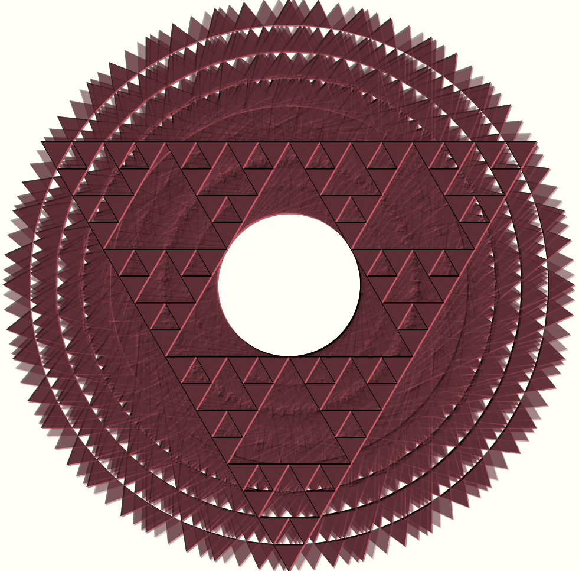

A friend of mine, David Kjellin, [publisher and artist](https://viktlosheten.wordpress.com/), who is into the border of art and poetry, always emphasizes the element of interaction, both with the material and the consumer, when making art of this kind.

Surely it does not convey meaning in the same way as other forms of art. But still, it conveys meaning just the same — not unlike instrumental music which conveys meaning, lacking lyrics. A form of non-linguistic communication that by speaking to emotions and senses may (or may not) trigger cognitive responses.

This kind of art cannot trigger cognitive responses (thoughts) in the same manner as literature, poems, or even medieval European art (in which symbols have a very clear meaning; often aiming to educate illiterates on the Bible).

Discussing this is quite meaningless in the sense that we cannot arrive at an answer. But sometimes the task of philosophy is not to provide answers, but to exclude possible answers.

Anyhow, it does not matter. I enjoy art like this and find it fascinating to compare some branches of modernism (and modernity) with artists like Wassily Kandinsky, Paul Klee, and others with the generative art made with computers.

Today, books are written about the beauty of scientific images (be it photographs of nebulas or an enlargement of some particle). Much of contemporary art seems preoccupied (too much I think, but this is not the time and place…) with abstract dealings. I think the love of beauty in shapes is something innate, a part of human nature. And generative art consists of nothing but shape and color.

An aspect I also enjoy is the interactivity. The element of ‘discovery’ and ‘chance’; how you mix with the ‘settings’, experiment and produce an experience you find aesthetically pleasing. Of course, there is nothing random about it (I am not speaking about random values in this context) — I think more of the aspect of our littleness, our inability to calculate beforehand how the end-result will turn out.

Although I would guess this experience is present in all artistic creations it is perhaps more apparent in a context such as this one? You’re not even enclosed in 3d, but can add “time” and permit a user to participate and co-create the art in dialogue with a set-up environment, a set of ‘rules’.

Here I have used a Sierpiński triangle — triangles inside triangles, recursively called to a specified depth —, a shadow effect, and rotation, spinning a triangle until a result crystallizes.

```javascript
function convertToRadians(degree) {
  return degree * (Math.PI / 180);
}

function sTriangle (context, depth = 4, angle = -Math.PI / 2, alpha = 0.05) {
  if(!context) {
    const canvas = document.querySelector('#animation');
    canvas.height = window.innerHeight;
    canvas.width = window.innerWidth;
    const ctx = canvas.getContext('2d');
    ctx.translate(canvas.width * 0.5, canvas.height * 0.5);
    ctx.scale(canvas.height * 0.5, canvas.height * 0.5);
    return sTriangle(ctx);
  }
  if (depth === 0) {
    context.beginPath()
    context.moveTo(Math.cos(angle), Math.sin(angle));
    for(let i = 0, a = angle; i < 3; a += Math.PI * 2 / 3, i++) {
      context.lineTo(Math.cos(a), Math.sin(a));
    }
    context.shadowBlur = 0;
    context.shadowOffsetX = 2;
    context.shadowOffsetY = 2;
    context.shadowColor = '#bf616a';
    context.fillStyle = `rgba(0,0,0,${alpha})`;
    context.fill();
  } else {
    for(let i = 0, a = angle; i < 3; a += Math.PI * 2 / 3, i++) {
      context.save();
      context.translate(Math.cos(a) * 0.5, Math.sin(a) * 0.5);
      context.scale(0.5, 0.5);
      sTriangle(context, depth - 1, angle, alpha + 0.02);
      context.restore();
    }
  }
  return context;
}

const drawingAngle = () => {
  let angle = 0;
  return () => angle > 360
    ? 0
    : angle++;
}

function animate(ctx) {
  ctx.rotate(convertToRadians(getAngle()));
  sTriangle(ctx);
  window.requestAnimationFrame(() => animate(ctx));
}

const initialContext = sTriangle();
const getAngle = drawingAngle();
window.requestAnimationFrame(() => animate(initialContext));
```

[About](https://bergsans.github.io/about) | [Archive](https://bergsans.github.io/)